# Individual Assignment 1

BA780 - Fall 2019

**Name:**

Total points: 20

(3 points) Please add your name on the top. Submit your homework in the form of an HTML extract of an R Notebook. Include the questions in your notebook for clarity.

### Problem 1

(3 points)

1. In the `mpg` dataset from *ggplot2* package, how would you describe the relationship between `cty` and `hwy`? Plot one graph with appropriate layers to explain this relationship.
2. Most likely you have done some overplotting in the previous question (which is OK). Can you suggest a method that overcomes this overplotting and gives a better insight about the relationship in the data?

**Answer:**

### Problem 2

(5 points)

1. Using the `mpg` dataset from *ggplot2* package, explore the 3-way relationship between fuel economy (`cty`), engine size (`displ`) and number of cylinders (`cyl`). By plotting `displ` vs. `cty` we can confirm that the bigger the engine the lower the gas mileage; how does bringing in the number of cylinders change your assessement of the relationship between engine size and fuel economy? (3 points)

Hint: Fitting a linear line will help you make a better judgement.

2. How can you explain the somewhat surprising outcome for 8 cylinder cars? Hint: use your visualization techniques to describe it. One possible explanation could be revealed by using `class` in conjunction with the other 3 aformentioned variables. (2 points)

**Answer:**

### Problem 3

(3 points)

Explore the distribution of the `carat` variable in the `diamonds` dataset from *ggplot2*. What binwidth reveals the most interesting patterns? Can you make an educated guess what this pattern reveals?

Hint: You may try different `bindwidth` to find a good demonstration of the pattern.

**Answer:**

### Problem 4

(6 points)

Create a ggplot function that contains the built-in `diamonds` dataset and an aesthetics layer. Map `carat` on the x axis and `price` on the y axis. Using + , add a `geom_point` with an `alpha` of `0.02`. Assign this initial plot to an object: `p`

Then add (+) `geom_smooth` layer to the `p` object. Map `clarity` to the color argument in the `geom_smooth` function (add `se=FALSE` to `geom_smooth` to turn off error shading). Add `theme_minimal` layer.

Note: the plot will take a few seconds to generate. Your plot should look similar to the one given below:

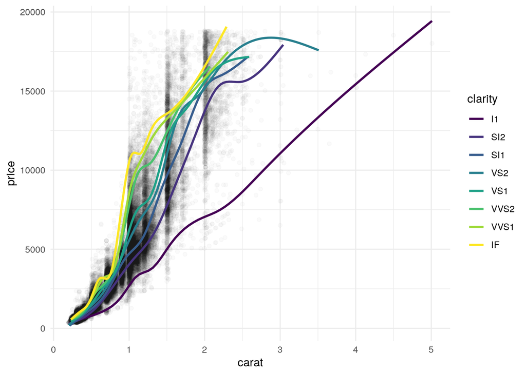

1. Reproduce this plot.
2. What is your observation?

**Answer:**